# R Notebook

```r
library(rpart)
library(rpart.plot)
library(tidyverse)

library(tidyverse)
titanic_set <- read_csv('data/titanic_decision_tree_data.csv')

shuffle_index <- sample(1:nrow(titanic_set))

# shuffle the data so class order isn't in order - need this for training/testing split later on
titanic_set <- titanic_set[shuffle_index, ]
```

Q1.1 Cleaning up the data is always the first step. Do the following:

```r
titanic_set %>%
  glimpse()
```

```
Rows: 1,309
Columns: 13
$ X1           <dbl> 571, 93, 374, 880, 495, 689, 1204, 661, 372, 1139, 753, 741, 307, 35, 1083, 1229…
$ passenger_id <dbl> 153, 984, 1265, 462, 77, 271, 786, 243, 1263, 721, 335, 323, 1198, 926, 665, 811…
$ pclass       <dbl> 3, 1, 2, 3, 3, 1, 3, 2, 1, 2, 1, 2, 1, 1, 3, 3, 1, 2, 3, 3, 3, 3, 3, 2, 2, 3, 3,…
$ name         <chr> "Meo, Mr. Alfonzo", "Davidson, Mrs. Thornton (Orian Hays)", "Harbeck, Mr. Willia…
$ sex          <chr> "male", "female", "male", "male", "male", "male", "male", "male", "female", "fem…
$ age          <dbl> 55.5, 27.0, 44.0, 34.0, NA, NA, 25.0, 29.0, 31.0, 6.0, NA, 30.0, 30.0, 30.0, 20.…
$ sib_sp       <dbl> 0, 1, 0, 0, 0, 0, 0, 0, 0, 0, 1, 0, 1, 1, 1, 0, 0, 2, 0, 0, 1, 0, 0, 1, 0, 1, 0,…
$ parch        <dbl> 0, 2, 0, 0, 0, 0, 0, 0, 0, 1, 0, 0, 2, 0, 0, 0, 0, 1, 0, 0, 4, 0, 0, 1, 0, 1, 0,…
$ ticket       <chr> "A.5. 11206", "F.C. 12750", "248746", "364506", "349208", "113798", "374887", "W…
$ fare         <dbl> 8.0500, 52.0000, 13.0000, 8.0500, 7.8958, 31.0000, 7.2500, 10.5000, 134.5000, 33…
$ cabin        <chr> NA, "B71", NA, NA, NA, NA, NA, NA, "E39 E41", NA, NA, NA, "C22 C26", "C78", NA, …
$ embarked     <chr> "S", "S", "S", "S", "S", "S", "S", "S", "C", "S", "S", "Q", "S", "C", "S", "S", …
$ survived     <dbl> 0, NA, NA, 0, 0, 0, 0, 0, NA, 1, 1, 1, NA, NA, 1, 0, 0, NA, 1, 0, 0, NA, 0, NA, …
```

Take only observations which have a survived flag (i.e. that aren’t missing)

```r
titanic_set <-
titanic_set %>%
  filter(!is.na(survived))
```

Turn your important variables into factors (sex, survived, pclass, embarkation)

```r
titanic_set <-
titanic_set %>%
  mutate(sex = as_factor(sex),
         survived = as_factor(survived),
         pclass = as_factor(pclass),
         embarked = as_factor(embarked))
```

Create an age_status variable which groups individuals under (and including) 16 years of age into a category called “child” category and those over 16 into a category called “adult”.

```r
titanic_set <-
titanic_set %>%
  mutate(age_status = if_else(age <= 16, "child", "adult"))
```

Drop the NA

```r
titanic_set <-
titanic_set %>%
  drop_na(age_status)
```

Drop any variables you don’t need (X1, passenger_id, name, ticket, far, cabin)

```r
titanic_set <-
titanic_set %>%
  select(-c(X1, passenger_id, name, ticket, fare, cabin))
```

Q1.2 Have a look at your data and create some plots to ensure you know what you’re working with before you begin. Write a summary of what you have found in your plots. Which variables do you think might be useful to predict whether or not people are going to die? Knowing this before you start is the best way to have a sanity check that your model is doing a good job.

```r
library(modelr)
library(broom)
library(GGally)

ggpairs(titanic_set)
```

[output not shown]

```r
titanic_split_1 <- titanic_set %>%
  select(sex, sib_sp, age, age_status, survived)

titanic_split_2 <- titanic_set %>%
  select(pclass, parch, embarked, survived)
```

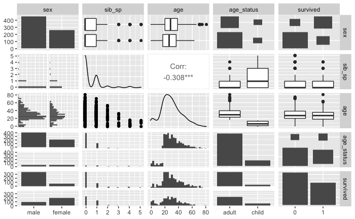

```r
ggpairs(titanic_split_1)
```

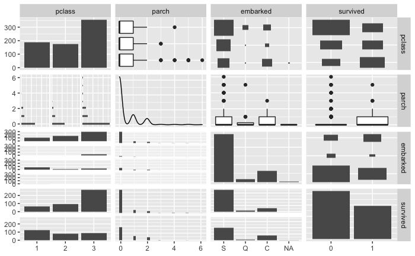

```r
ggpairs(titanic_split_2)
```

**Looking at the two sets of plots, I’m focusing exclusively on the survived column as the responsive variable that we want to explore along with it’s interactions with the other potential predictors. So to start, sex definitely seems to show some potential as a predictor. Although age looks less likely to be a significant predictor, age status does seem to show more potential. Amongst the second split, pclass certainly looks like it could be a useful predictor. To a lesser extent both parch and embarked seem to show a little divergence so these could also be worth exploring, but only if really necessary. So in terms of an early ranking of what would be useful to consider as a predictor:**

*1. Sex* *2. Pclass* *3. Age_Status* *4. Parch* *5. Embarked* *6. Age* *7. sib_sp*

Q3. Now you can start to build your model. Create your testing and training set using an appropriate split. Check you have balanced sets. Write down why you chose the split you did and produce output tables to show whether or not it is balanced. [Extra - if you want to force balanced testing and training sets, have a look at the stratified() function in package splitstackshape (you can specify multiple variables to stratify on by passing a vector of variable names to the group argument, and get back testing and training sets with argument bothSets = TRUE)]

```r
titanic_n_data <- nrow(titanic_set)

test_index <- sample(1:titanic_n_data, size = titanic_n_data*0.15)

# make our datasets

titanic_test <- slice(titanic_set, test_index)
titanic_train <- slice(titanic_set, -test_index)
```

**Since we’ve been using a pretty consistent 80:20 split for train and test respectively, I thought I change it a little to see what effect this might have. Having a look online, it looks like the larger the data set, the larger the proportion of the overall data could potentially be reserved to be used as test data. With this in mind, I thought I’d be fine to see what happened with a relatively small dataset and a split of 85:15. This leads to about 600 for the training and 100 for the test which seems alright.**

```r
titanic_test
```

[output not shown]

Q1.4 Create your decision tree to try and predict survival probability using an appropriate method, and create a decision tree plot.

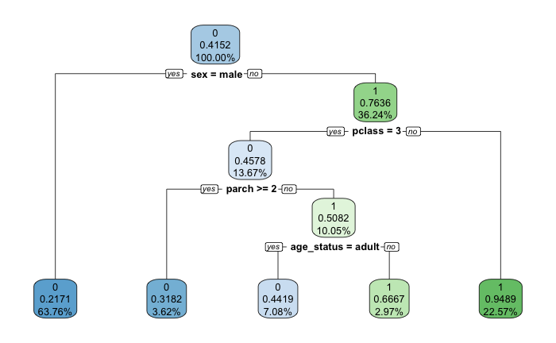

```r
#Going to take the first 3 from our ranking above here. So sex, pclass and age_status

library(rpart)
library(rpart.plot)

titanic_fit_sex <- rpart(survived ~ sex + pclass + age_status + parch,
                     data = titanic_train,
                     method = "class")

rpart.plot(titanic_fit_sex,
           digits = 4,
           yesno = 2)
```

*Just realised I haven’t fully checked or understood exactly what “parch” means!! It’s described as “number of parents / children aboard the Titanic. Some children travelled only with a nanny, therefore parch=0 for them”. I just want to check if this refers to just children or it also shows a relationship for adults.*

```r
titanic_set %>%
  distinct(parch)
```

[output not shown]

```r
#Right, so it must be a two-way signifier showing how many of either parents or children on board each individual has.
titanic_set %>%
  filter(age_status == "adult")
```

[output not shown]

*Going back to the above decision tree, I think this is quite interesting. First off all, it seems like sex is indeed the main predictor of survival rates. The bottom left node shows that, only 21% of males are predicted to survive based on the training data, with males accounting for nearly 2/3rds of the overall dataset.*

*Amongst females, it seems there is quite a dramatic split between those travelling in 3rd class and all other classes. Females that are not in 3rd class make up around just over 22% of the overall dataset and are the most likely to survive in this model, with a predicted survival rate of 95%. We see a drop of almost 50% in absolute survival rates among females in 3rd class, predicted at 45%.*

*Finally, in our model, we have 1 odd finding and one expected finding amongst the 3rd class females. Firstly, it looks like if you have less than 2 parents/children also on board, you’re chancing of surviving are improved by aroud 20% (50% to 31%). Within those females who traveleed in 3rd class and do have less that two parent/children also aboard, being classed as an adult makes you more than 20% difference less likely to survive surviving (44% to 66%)*

Going to be cheeky and see what it looks like when we bung all the variables in.

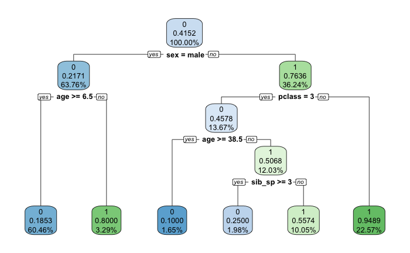

```r
titanic_fit_all <- rpart(survived ~ .,
                     data = titanic_train,
                     method = "class")

rpart.plot(titanic_fit_all,
           digits = 4,
           yesno = 2)
```

*So it’s quite interesting when age is added back in a a continuous variable rather than with our two statuses. Strangely, the value that we most discounted, sib_sp, makes an appearance within this chart. The first two levels remain the same amoungst females, with an added caveat being added to male survival rates based on being over 6.5 years old*.

Q1.6 Test and add your predictions to your data. Create a confusion matrix. Write down in detail what this tells you for this specific dataset.

```r
titanic_test_pred_4 <- titanic_test %>%
  add_predictions(titanic_fit_sex, type = "class")
```

```r
library(yardstick)

titanic_conf_mat_pred_4 <- titanic_test_pred_4 %>%
  conf_mat(truth = survived, estimate = pred)

titanic_conf_mat_pred_4
```

```
          Truth
Prediction  0  1
         0 67 15
         1  2 23
```

```r
titanic_accuracy <- titanic_test_pred_4 %>%
  accuracy(truth = survived,
           estimate = pred)

titanic_accuracy
```

| .metric | .estimator | .estimate |
| --- | --- | --- |
| accuracy | binary | 0.8411215 |

*So it looks like we got about 84% accuracy on our test data after developing the model in our training set.I think it would be fun to have a look at what sort of accuracy we get with all the variables lumped in*

```r
titanic_test_pred_all <- titanic_test %>%
  add_predictions(titanic_fit_all, type = "class")
```

```r
titanic_conf_mat_pred_all <- titanic_test_pred_all %>%
  conf_mat(truth = survived, estimate = pred)

titanic_conf_mat_pred_all
```

[output not shown]

```r
titanic_accuracy_all <- titanic_test_pred_all %>%
  accuracy(truth = survived,
           estimate = pred)

titanic_accuracy_all
```

| .metric | .estimator | .estimate |
| --- | --- | --- |
| accuracy | binary | 0.7850467 |